# Testing for Tolerance in a Box Experiment in Wild Vervet Monkeys - M.AungKyaw - 2022-2023

juin 19, 2024 18:43

[figure not shown]

# 0.Opening the data

### Loading data

- First I downloaded the **knitr package** to create outputs as html, pdf or word files when knitting my r markdown file. I also loaded the **pander** package for better presentation
- The **dplyr** package was installed for better manipulation of the data as filtering or creating new variables and **lubridate** for a better manipulation of dates and time
- Then, I installed the **readxl package** to import my dataset which is called **Box Experiments.xls**
- This dataset contains information related to my master thesis project. I used cyber tracker in order to record the behaviors of dyads of Vervet monkeys in a box experiment on tolerance from September 2022 to September 2023

# 1.Explore the data

### Description of the initial datset - “Boxex”

```
## Glimpse of the Box Experiment dataset:
```

```
## Rows: 2,795
## Columns: 20
## $ Date                  <dttm> 2022-09-27, 2022-09-27, 2022-09-27, 2022-09-27,…
## $ Time                  <dttm> 1899-12-31 09:47:50, 1899-12-31 09:50:07, 1899-…
## $ Data                  <chr> "Box Experiment", "Box Experiment", "Box Experim…
## $ Group                 <chr> "Baie Dankie", "Baie Dankie", "Baie Dankie", "Ba…
## $ GPSS                  <chr> "-28.010549999999999", "-28.010549999999999", "-…
## $ GPSE                  <chr> "31.191050000000001", "31.191050000000001", "31.…
## $ MaleID                <chr> "Nge", "Nge", "Nge", "Nge", "Nge", "Nge", "Nge",…
## $ FemaleID              <chr> "Oerw", "Oerw", "Oerw", "Oerw", "Oerw", "Oerw", …
## $ `Male placement corn` <dbl> NA, NA, NA, NA, NA, NA, NA, NA, NA, NA, NA, NA, …
## $ MaleCorn              <dbl> 3, 3, 3, 3, 3, 3, 3, 3, 3, 3, 3, 3, 3, 3, 3, 3, …
## $ FemaleCorn            <dbl> NA, NA, NA, NA, NA, NA, NA, NA, NA, NA, NA, NA, …
## $ DyadDistance          <chr> "2m", "2m", "1m", "1m", "0m", "0m", "0m", "0m", …
## $ DyadResponse          <chr> "Tolerance", "Tolerance", "Tolerance", "Toleranc…
## $ OtherResponse         <chr> NA, NA, NA, NA, NA, NA, NA, NA, NA, NA, NA, NA, …
## $ Audience              <chr> "Obse; Oup; Sirk", "Obse; Oup; Sirk", "Oup; Sirk…
## $ IDIndividual1         <chr> NA, NA, NA, NA, NA, NA, NA, NA, NA, NA, NA, NA, …
## $ IntruderID            <chr> NA, NA, NA, NA, NA, NA, NA, NA, NA, NA, NA, "Sey…
## $ Remarks               <chr> NA, NA, "Nge box did not open because of the bat…
## $ Observers             <chr> "Josefien; Michael; Ona; Zonke", "Josefien; Mich…
## $ DeviceId              <chr> "{7A4E6639-7387-7648-88EC-7FD27A0F258A}", "{7A4E…
```

| Date | Time | Data | Group | GPSS | GPSE | MaleID | FemaleID | Male placement corn | MaleCorn | FemaleCorn | DyadDistance | DyadResponse | OtherResponse | Audience | IDIndividual1 | IntruderID | Remarks | Observers | DeviceId |
| --- | --- | --- | --- | --- | --- | --- | --- | --- | --- | --- | --- | --- | --- | --- | --- | --- | --- | --- | --- |
| 2022-09-27 | 1899-12-31 09:47:50 | Box Experiment | Baie Dankie | -28.010549999999999 | 31.191050000000001 | Nge | Oerw | NA | 3 | NA | 2m | Tolerance | NA | Obse; Oup; Sirk | NA | NA | NA | Josefien; Michael; Ona; Zonke | {7A4E6639-7387-7648-88EC-7FD27A0F258A} |
| 2022-09-27 | 1899-12-31 09:50:07 | Box Experiment | Baie Dankie | -28.010549999999999 | 31.191050000000001 | Nge | Oerw | NA | 3 | NA | 2m | Tolerance | NA | Obse; Oup; Sirk | NA | NA | NA | Josefien; Michael; Ona; Zonke | {7A4E6639-7387-7648-88EC-7FD27A0F258A} |
| 2022-09-27 | 1899-12-31 09:53:11 | Box Experiment | Baie Dankie | -28.010549999999999 | 31.191050000000001 | Nge | Oerw | NA | 3 | NA | 1m | Tolerance | NA | Oup; Sirk | NA | NA | Nge box did not open because of the battery. Oerw vocalized to MA when he ap to the box to open it. | Josefien; Michael; Ona; Zonke | {7A4E6639-7387-7648-88EC-7FD27A0F258A} |
| 2022-09-27 | 1899-12-31 09:54:28 | Box Experiment | Baie Dankie | -28.010549999999999 | 31.191050000000001 | Nge | Oerw | NA | 3 | NA | 1m | Tolerance | NA | Sirk | NA | NA | Sey came to the boxes once they were open | Josefien; Michael; Ona; Zonke | {7A4E6639-7387-7648-88EC-7FD27A0F258A} |
| 2022-09-27 | 1899-12-31 09:55:19 | Box Experiment | Baie Dankie | -28.010549999999999 | 31.191050000000001 | Nge | Oerw | NA | 3 | NA | 0m | Tolerance | NA | Sey; Sirk | NA | NA | NA | Josefien; Michael; Ona; Zonke | {7A4E6639-7387-7648-88EC-7FD27A0F258A} |
| 2022-09-27 | 1899-12-31 09:56:56 | Box Experiment | Baie Dankie | -28.010549999999999 | 31.191050000000001 | Nge | Oerw | NA | 3 | NA | 0m | Tolerance | NA | Sey; Sirk | NA | NA | NA | Josefien; Michael; Ona; Zonke | {7A4E6639-7387-7648-88EC-7FD27A0F258A} |

- I am now using the **View** function to have a sight on the entire dataset and **glimpse** to display a summary of my dataset
- I have **20 variables** (here columns) and **2795 trials** (here rows)
- I will now make a brief summary of each variables and their use before creating a new dataframe (df) with my variables of interest that I will call **Bex**
- The highlighted variables are the ones I will use for **Bex**. I will then **clean the data** before heading to the **statistical analysis** and the **interpretation of the results**

#### Variables of Boxex

- **Date** : “Date” is in a **POSIXct** format which is appropriate for the display of time
  - I want to use the date to know **how many sessions** have been done with each dyads in my experiment.
  - I will create a variable called **Session** where **1 session = 1 day**
  - The data has values from the **14th of September 2022** until the **13th of September 2023**
  - I may consider separating the **12 months** of data in **4 seasons** to make a preliminary check of a potential effect of seasonality. Nevertheless since we did not use any tools to measure the weather, temperature, humidity or food availability (also related to seasonality and weather). Categorizing my data in 4 without having further data would then be quite arbitrary. If I end up doing it in my report, it will be done without any intention to include it in my scientific analysis nor my scientific report .
- **Time** : “Time is coded” in a **POSIXct** format
  - I do not plan to use this variable but we can see that “Time” has the correct hours displayed with a date which is incorrect.
  - (In the case I wanted to observe **when the trials occurred during the day** as time may have an influence on their behavior (**Isbell & Young 1993**)) I would need to correct the incorrect display of the date in the dataset.
  - This variable could also be useful to see when the **seasonal effect** took place as we only went in the morning during summer because of the heat while we went later and for longer times in the field to do the box experiment in winter
  - For now, the values in “Time” are all on the same (wrong) day which is the **31st of December**
  - Note: I first did not intend to keep **Time** in Bex but I needed this variable to see the order of the trails within a day. I finally decided to keep it.
- Data : chr “Data” is coded as **character**
  - It describes **the type of data** being recorded in the software **cybertracker**. We installed the software on tablets to record the different behaviors of vervet monkeys in our research center
  - In our case, my data was recorded in cybertracker as **Box Experiment** as we created a form specifically for this experiment
  - For this reason we can remove this column since the information it contains is unecessary and redundant
- Group : chr The data is coded in r as a **character**
  - It describes the **group of monkey** in which we did the trial
  - I will keep this column to see the amount of trials that we did in the 3 group of monkeys which are Baie-Dankie **(BD)**, Ankhase **(AK)**, and Noha **(NH)**
- GPSS : num “GPSS” is coded as **numerical**
  - It gives the **south coordinates** in which we started the experiment
  - I do not plan to use coordinates nor look at locations so I will remove this acolumn
- GPSE : num “GPSE” is coded in as **numerical**
  - It gives the **east coordinates** in which we started the experiment
  - I do not plan to use coordinates nor look at locations so I will remove this column
- **MaleID** : chr “MaleID” is coded as **character**
  - It indicates the **name of the male involved in the trial**
  - I plan to use this to see how factors related to the individual may influence the experiment (age, sex, rank)
  - It will also help me see which behaviour was displayed by each individuals (here males)
- **FemaleID** : chr “FemaleID” is coded as **character**
  - It indicates the **name of the female involved in the trial**
  - I plan to use this variable in the same way as “Male ID”
  - It will also help me see which behaviour was displayed by each individuals (here females)
- **Male placement corn**: dbl “Male placement corn is coded in r as **double**
  - It gives the **amount of corn given to the male of the dyad before the trials**
  - Within a session it happened that we gave more placement corn to attract the monkeys again to the boxes. This lead to an update of the number in the same session. The number found at the end of the session is the total placement corn an individual has received
  - I will fuse this column with **male corn** as the data has been separated between these two variables. This is due to a mistake when creating the original box experiment form in cybertracker
  - This variable could be related to the level of motivation of a monkey but as it is not directly related to my hypothesis I may not use this column. I will re-consider the use of this column later on
  - In regards of this possibility I will change the format of the variable to numerical
- **MaleCorn** : dbl “MaleCorn” is coded in r as **double**
  - It gives the same information as in **male placement corn**
  - I will import the values from “male placement corn” into this one
  - I will change the format of the variable to numerical
- **FemaleCorn** : dbl The data is coded in r as **double**
  - It gives the **amount of corn given to the female of the dyad before the trials**
  - It works in the same way as “male placement corn”/“MaleCORN”
  - I will change the format of the variable to numerical
- **DyadDistance** : chr The data is coded in r as **character**
  - It gives the **distance for each trial** that we have done with the dyads.
  - The trial number 1 for each dyad was at 5 meters.
  - The maximum was around 10 m while the minimum is 0
  - We will have to remove the “m” for meters in order to have a numerical variable instead of character
  - Also, since the very first trials per dyad can be considered as a kind of learning phase, i may remove the **15 first trials** that were made for each dyad
- **DyadResponse** : chr The data is coded in r as **character**
  - It indicated which **behaviour was produced by the dyad’s during each trial**
  - The different behaviours were: **Distracted**, **Female aggress male**, **Male aggress female**, **Intrusion**, **Loosing interest**, **Not approaching**, **Tolerance** and **Other**
  - I will change the columns associated to each behavior (i.e. Response) of **DyadResponse** into dichotomic variables in order to see the frequency of each behaviour
  - This will allow me to see which behavior occurred more ,and behavioural differences could be found between dyads
  - As multiple response could occur within the same trial, multiple behaviors can be found in a single cell. I will create a hierarchy to reduce the amount of behaviors assigned to each trial (if there is more than one). This will also be complemented with the information found in the column **remarks**
    1. correct any mistakes (ex. if tolerance and aggression are together aggression>tolerance)
    2. assign as few labels per trial
    3. get a better View and understanding of the data and the most common behaviours produced by each dyad
    4. create variables that can complement the behaviour found (ex. not approaching + looks at partner would be looks at partner + a new variable called hesistant to see when the did not come but look at the other individual / )
  - Projection of the hierarchy (changes will be made)
    - Create a table with each combination existing
    - Decide what is more important
    - Ex:
      - Aggression > Tolerance
      - Tolerance > Not approaching -> Create a variable called hesistant in addtion to the tolerance count to see frequency of tolerance behaviour that happened after > 1min
      - Tolerance > Loosing interest
      - Tolerance > Intrusion
      - Not approaching = looking box but not coming while Loosing interest = not paying attention to the box
      - Intrusion > Loosing interest
      - Intrusion > Not approaching
      - Not approaching > Looks at partner
      - We can code every look at partner as no approaching and keep the count of looks at partner as additional information
      - Not approaching >?> Loosing interest ? !!
      - Define distracted
      - Not approaching > Distracted
      - Aggression > Not approaching
      - Other > Look case by case and categorize depending of behavior
      - Remarks may be used for the same reason
- **OtherResponse** : chr “The data”OtherResponse” is coded as **character**
  - It describes **any behaviour that is different from the ones found in Dyad Response** (meaning ≠ tolerance, aggression, intrusion, loosing interest, not approaching, distracted, looks at partner that where categorized as **other**)
  - I will have to look at every **OtherResponse** and rename each entry in one of the response already if existing. I will proceed case by case.
  - If I want to do an intermediate manipulation I may rename every NA in “OtherResponse” into **Response** to see the amount of case to treat and how many occurrences seem to not fit in the categories of “DyadResponse”
- **Audience** : chr “Audience” is in r as **character**
  - It gives the **names of the individuals in the audience**
  - I would like to use it to see the **amount of audience (big vs small)** and the **dominance level of the audience (high vs low)**
  - I will create a variable called **NAudience** to see hoy many individuals are in the audience for each trial
  - After calculating the elo ratings of the individuals using another dataset (Life history), I will create a dichotomic variable called **RankAudience** to see effects related to rank with the effect of audience
- **IDIndividual1** : chr “IDIndividual1” is coded in r as **character**
  - It gives the **names of the individuals that did not approach, showed aggression, got distracted or lost interest** during a trial
  - I will have to look at it to see how often these behaviors occurred
  - I will consider how to use this variable during the cleaning of the data
- **IntruderID** : chr “IndtruderID” is coded as **character**
  - It gives the **name of the individual that intruded the experiment during a trial**
  - Intrusion could mean, invade the space of the experiment and interact with one of our individual, steal the food, show agnostic behavior, stand in very close proximity of the dyad’s individuals
- **Remarks** : chr The data is coded in r as **character**
  - It gives either additional information concerning the experiment when unusual behaviors occurred , mistakes that needed to be corrected or details that we wanted to record in case we would need them
- Observers :chr The data is coded in r as **character**
  - It gives the **names of the observers during the experiment**
  - We will not use this data as we do not look at the effect that an experimenter would have on the monkeys
  - (Should I still look at an effect of the amount of experimenter?…maybe better for detailled analysis of our study)
- DeviceID :chr “The data”DeviceID” is coded in r as **character**
  - It gives the **name of the device/tablet** used to record the data during the experiment
  - We will not use this data either

# 2. Treating missing data

## 2.1. Creating a new dataframe - Bex

- Since I do not want to work with the whole dataset, I’m gonna select the variables of interest using the function **select**
- I will keep Time, Date, Group, MaleID, FemaleID, MaleCorn, Male placement corn, FemaleCorn, DyadDistance, DyadResponse, OtherResponse, Audience, IDIndividual1, IntruderID, Remarks

```
## Rows: 2,795
## Columns: 15
## $ Time                  <dttm> 1899-12-31 09:47:50, 1899-12-31 09:50:07, 1899-…
## $ Date                  <dttm> 2022-09-27, 2022-09-27, 2022-09-27, 2022-09-27,…
## $ Group                 <chr> "Baie Dankie", "Baie Dankie", "Baie Dankie", "Ba…
## $ MaleID                <chr> "Nge", "Nge", "Nge", "Nge", "Nge", "Nge", "Nge",…
## $ FemaleID              <chr> "Oerw", "Oerw", "Oerw", "Oerw", "Oerw", "Oerw", …
## $ MaleCorn              <dbl> 3, 3, 3, 3, 3, 3, 3, 3, 3, 3, 3, 3, 3, 3, 3, 3, …
## $ `Male placement corn` <dbl> NA, NA, NA, NA, NA, NA, NA, NA, NA, NA, NA, NA, …
## $ FemaleCorn            <dbl> NA, NA, NA, NA, NA, NA, NA, NA, NA, NA, NA, NA, …
## $ DyadDistance          <chr> "2m", "2m", "1m", "1m", "0m", "0m", "0m", "0m", …
## $ DyadResponse          <chr> "Tolerance", "Tolerance", "Tolerance", "Toleranc…
## $ OtherResponse         <chr> NA, NA, NA, NA, NA, NA, NA, NA, NA, NA, NA, NA, …
## $ Audience              <chr> "Obse; Oup; Sirk", "Obse; Oup; Sirk", "Oup; Sirk…
## $ IDIndividual1         <chr> NA, NA, NA, NA, NA, NA, NA, NA, NA, NA, NA, NA, …
## $ IntruderID            <chr> NA, NA, NA, NA, NA, NA, NA, NA, NA, NA, NA, "Sey…
## $ Remarks               <chr> NA, NA, "Nge box did not open because of the bat…
```

### 2.1.1 Merging Male placement corn and MaleCorn

- I want to process all the missing data in Bex. But before, I will merge the column **MaleCorn** and **Male placement corn** as the data of both columns is supposed to be together under “MaleCorn”
- Looking manually in the Bex table it seems that very few data is in **MaleCorn** while most of it seems to be in **Male placement corn**
- Every time there is a missing value in Male placement corn we can see a value in Male Corn, I will then create a new variable MaleCorn where every time that there is NA in male placement corn the value will be taken in MaleCornOld (previous malecorn). If there is no NA it will take the value of ´Male placement corn´
- I will first **rename MaleCorn to MaleCornOld**, then **check the amount of NA’s** and then **merge “MaleCornOld” and “male placement corn”** into the **new variable “MaleCorn”**

```
## Number of rows with common NAs in MaleCornOld and 'Male placement corn': 1499
## Number of occurrences of 0 in MaleCorn: 1499
## Number of remaining NA values in MaleCorn: 0
```

- I have found **1499 NA in common** between MaleCornOld and ‘male placement corn’, **1609 NA in Male placement corn** and **2685 in MaleCorn old**
- For the **merge of MaleCornOld and Male placement corn**, I used different conditions: 1.In this code, a new variable MaleCorn is created. If there is a missing value in Male placement corn, it takes the corresponding value from MaleCornOld; otherwise, it takes the value from Male placementcorn. 2.If there are no value in both MaleCornOld and Male placement corn (NA,NA) for a given row, I would like the code to display 0 as it means that no placement was given
- In this way, I should not loose any data, minimize the mistakes and already transform the NA’s of this variable into a number which will remove the remaining NA’s which are meant to be 0
- After the merge I found that there were **no NA’s remaining** in the **“New” Male Corn** and that **1499 0’s** where found in the column which **corresponds to the amount of common NA’s found previously** between the **“Old” Male Corn** and **male placement corn**

### 2.1.2 Cleaning FemaleCorn

```
## Number of remaining NA values in FemaleCorn: 0
```

### 2.2 Cleaning variables with missing data

- Now in order to see where are located the missing points in the data, I’m going to **print** the variables **with and without NA’s**
- The function **sapply** is used to apply the function **sum** for NA’s to each column of the data frame, so each variable

```
## Variables with Missing Data:
```

|  | x |
| --- | --- |
| MaleID | 19 |
| FemaleID | 60 |
| DyadDistance | 33 |
| DyadResponse | 47 |
| OtherResponse | 2758 |
| Audience | 924 |
| IDIndividual1 | 2143 |
| IntruderID | 2737 |
| Remarks | 2181 |

```
## Variables with No Missing Data:
```

|  | x |
| --- | --- |
| Time | 0 |
| Date | 0 |
| Group | 0 |
| FemaleCorn | 0 |
| MaleCorn | 0 |

- We can see that out of the 14 variables we have in **Bex** we have **9 variables with missing data** which are **Male ID, Female ID, DyadDistance, DyadResponse, OtherResponse, Audience, IDIndividual1, IntruderID, Remarks**: I will proceed to clean these variables one by one
- MaleID 19
- FemaleID 60
- DyadDistance 33
- DyadResponse 47
- OtherResponse 2758
- Audience 924
- ID Individual1 2143
- IntruderID 2737
- Remarks 2181
- Before making treating the NA’s in the dataset I will make a backup of the data at this point:

### 2.3 Treating variables with missing data

#### 2.3.1 Cleaning “Remarks” - (2181 NA’s)

- Since most of the time we did not have any remarks it is understandable that this variable contains 2181 NA’s out of 2795 rows
- I will first transform every missing data in the column Remark into **No Remarks** and then check that the amount of “No remarks” found
- After the changes we can effectively see that we have **2181 “No Remarks”** and we have no missing data left in that column, I will treat this column by hand once all the NA’s have been removed from the dataset

```
## Number of 'No Remarks' in the 'Remarks' column: 2181
```

```
##
## No Remarks    Remarks
##       2181        614
```

### 2.3.2 Cleaning “Intruder ID” - (2737 NA’s)

- **Intruder ID** is a variable that contains the **name of the individuals that made and intrusion during a trial**.
- If more than one individual intruded, his name may be in the comments, which I will check when treating the data from this column
- Because nothing was entered when there was no intrusion, I will replace every NA’s by **No Intrusion**
- Also, I will use a function to create a new dichotomic variable called **Intrusion**. Every time there is a value in IntruderID, it should display 1 (Yes), if not a 0 (No intrusion)

```
## Number of 'No Intrusion' in the 'Intruder ID' column after replacement: 2737
```

- We previously had 2737 NA’s in IntruderID while now we have the same amount of occurrences of IntruderID which shis that the transformation went as intended

#### 2.3.3 Cleaning “IDIndividual1” - (2143 NA’s)

- IDIndividual1 is meant to report the name of the individual that did a behavior such as not approach, show aggression or loose interest during a trial
- I will now replace every NA in this column by **No individual** and print the amount of NA’s left and the amount of changes made

```
## Number of NAs replaced in IDIndividual1: 2143
## Number of remaining NA values in IDIndividual1: 0
```

### 2.6 Cleaning “Audience” - (924 NA’S)

- Audience is made to report every name of individuals around our dyad during a given trial
- I will replace every NA by **No audience** as no entry means the absence of other individuals around
- I will also create a new variable called “Amount audience” that will have to tell me how many individuals are found in the column Audience

```
## Number of changes made in 'Audience': 924
```

```
## Remaining NA values in 'Audience': 0
```

### 2.7 Cleaning “OtherResponse” - (2758 NA’S)

```
## Number of changes made in 'OtherResponse': 2758
```

```
## Remaining NA values in 'OtherResponse': 0
```

### 2.8 Cleaning of “Time”

- Since the reading of the data is more complicated without the time, which was usefull to know which trial was before or after, I changed the code made for Bex and added **Time** in the dataframe. Since I will need it for the cleaning of Dyaddistance, I will now extract the time from the date. Even if the date is wrong as seen in the first output, the time is correct. As in the second output, only the time has been kept

```
## [1] "1899-12-31 09:47:50 UTC" "1899-12-31 09:50:07 UTC"
## [3] "1899-12-31 09:53:11 UTC" "1899-12-31 09:54:28 UTC"
## [5] "1899-12-31 09:55:19 UTC" "1899-12-31 09:56:56 UTC"
```

```
## [1] "09:47:50" "09:50:07" "09:53:11" "09:54:28" "09:55:19" "09:56:56"
```

### 2.9 Cleaning DyadDistance

- Before looking at the NA’s of Dyaddistance I will remove the “m” that is in front of every number to have a numerical variable
- Then I will look at the location of the NA’s in the data to treat them case by case.

```
## # A tibble: 69 × 16
##    Time     Date                Group    MaleID FemaleID FemaleCorn DyadDistance
##    <chr>    <dttm>              <chr>    <chr>  <chr>         <dbl>        <dbl>
##  1 12:09:34 2022-09-27 00:00:00 Baie Da… Xia    Piep              7           NA
##  2 12:13:28 2022-09-27 00:00:00 Baie Da… Xia    Piep              7           NA
##  3 16:02:32 2022-09-15 00:00:00 Ankhase  Sho    Ginq              6           NA
##  4 10:46:33 2023-08-17 00:00:00 Baie Da… Xia    Piep              0           NA
##  5 09:30:17 2023-07-29 00:00:00 Baie Da… Xin    Ouli              0           NA
##  6 12:08:51 2023-07-11 00:00:00 Baie Da… Xia    Piep              0           NA
##  7 13:30:07 2023-06-29 00:00:00 Baie Da… Sey    Sirk              0           NA
##  8 09:54:24 2023-06-27 00:00:00 Ankhase  Sho    Ginq              0           NA
##  9 10:13:56 2023-06-23 00:00:00 Ankhase  Sho    Ginq              0           NA
## 10 09:39:04 2023-06-15 00:00:00 Ankhase  Sho    Ginq              2           NA
## # ℹ 59 more rows
## # ℹ 9 more variables: DyadResponse <chr>, OtherResponse <chr>, Audience <chr>,
## #   IDIndividual1 <chr>, IntruderID <chr>, Remarks <chr>, MaleCorn <dbl>,
## #   Intrusion <dbl>, AmountAudience <dbl>
## Number of NA values in DyadDistance column (using second approach): 69
## Rows with NA values in DyadDistance column: 24, 27, 95, 492, 744, 971, 1113, 1130, 1164, 1261, 1341, 1396, 1491, 1583, 1683, 1693, 1717, 1718, 1719, 1724, 1725, 1739, 1755, 1756, 1757, 1764, 1779, 1782, 1792, 1799, 1800, 1840, 1841, 1868, 1869, 1888, 1891, 1892, 1896, 1911, 1912, 1915, 1918, 1919…
```

- We have 69 missing values in DyadDistance. I will look at each row in it’s context as the actual distance of the box was always dependent of the previous trials. I will start with the bigger number as for now the oldest trial is at the last row while the closest one is in row 1.
  - If **tolerance** was achieved **twice in a row** = <1m
  - If **aggression** (male agress female or female agress male), not approaching,or **loosing interest** occured = >1m
  - If **distracted** or **intrusion** occured = same distance
  1. **24** - In trial23 (0m) there was aggression then at trial24 (1m) there was tolerance. The 24th trial is supposed to be at **1m**
  2. **27** - In trial25 (1m) there was not approaching then at trial26 (2m) there was tolerance.The 25th trial is supposed to be at **2m**
  3. **95** - In trial93 (2m ) there was male agress female then at trial 94 (3m) there was not approaching. The 95th trial is supposed to be at **4m**
  4. **492** - In trial490 (0m) there was tolerance then at trial491 (0m) there was tolerance. The 492nd trial is supposed to be at **0m**
  5. **744** - In trial742 (3m) there was aggression then at trial743 (4m) there was tolerance. The 744th trial is supposed to be at **4m**
  6. **971** - In trial969 (0m) there was tolerance then at trial970 (0m) there was tolerance. The 971st trial is supposed to be at **0m**
  7. **1113** - In trial1111 (2m) there was tolerance then at trial1112 (0m) there was tolerance. The 1113th trial is supposed to be at **0m**
  8. **1130** - In trial1128 there was another dyad so we can not use this cell. Then at trial1129 (3m) there was not approaching. Nevertheless, we don’t have any DyadResponse, i will thus **delete this row**
  9. **1164** - In trial1162 (3m) there was not approaching then at trial1163 (3m) there was not approaching. The 1164th trial is supposed to be at **4m**
  10. **1261** - The two preivous trials were made with another Dyad. Also DyadResponse is not available. I will thus **delete this row**
  11. **1341** - In trial1339 (0m) there was tolerance then at trial1340 (0m) there was tolerance. The 1341st trial is supposed to be at **0m**
  12. **1396** - The two previous trials were made with another Dyad. Also DyadResponse is not available. I will thus **delete this row**
  13. **1491** - The two previous trials were made with another Dyad. Also DyadResponse is not available. I will thus **delete this row**
  14. **1583** - In trial1581 (2m) there was not approaching and intrusion then at trial1582 (2m) there was not approaching. The 1583rd trial is supposed to be at **3m**
  15. **1683** - One trial only was made with tolerance (2m) but since there are no DyadResponse I will **delete this row**
  16. **1693** - The two previous trials were made with another Dyad. Also DyadResponse is not available. I will thus **delete this row**
  17. **1717** - The two previous trials were made with another Dyad. Also DyadResponse is not available. I will thus **delete this row**
  18. **1718** - The two previous trials were made with another Dyad. Also DyadResponse is not available. I will thus **delete this row**
  19. **1719** - The two previous trials were made with another Dyad. Also DyadResponse is not available. I will thus **delete this row**
  20. **1724** - The two previous trials were made with another Dyad. Also DyadResponse is not available. I will thus **delete this row**
  21. **1725** - The two previous trials were made with another Dyad. Also DyadResponse is not available. I will thus **delete this row**
  22. **1739** - The two previous trials were made with another Dyad. Also DyadResponse is not available. I will thus **delete this row**
  23. **1755** - since there are no DyadResponse I will **delete this row**
  24. **1756** - The two previous trials were made with another Dyad. Also DyadResponse is not available. I will thus **delete this row**
  25. **1757** - The two previous trials were made with another Dyad. Also DyadResponse is not available. I will thus **delete this row**
  26. **1764** - Since there are no DyadResponse I will **delete this row**
  27. **1779** - It seems like it was the first trial of the Dyad Pom Xian, if so, the distance has to be **5m**
  28. **1782** - The two previous trials were made with another Dyad. Also DyadResponse is not available. I will thus **delete this row**
  29. **1792** - Trial1791 was intrusion (4m) so this trial should be at **4m**
  30. **1799** - The two previous trials were made with another Dyad. Also DyadResponse is not available. I will thus **delete this row**
  31. **1800** - The two previous trials were made with another Dyad. Also DyadResponse is not available. I will thus **delete this row**
  32. **1840** - The two previous trials were made with another Dyad. Also DyadResponse is not available. I will thus **delete this row**
  33. **1841** - The two previous trials were made with another Dyad. Also DyadResponse is not available. I will thus **delete this row**
  34. **1868** - The two previous trials were made with another Dyad. Also DyadResponse is not available. I will thus **delete this row**
  35. **1869** - The two previous trials were made with another Dyad. Also DyadResponse is not available. I will thus **delete this row**
  36. **1888** - he two previous trials were made with another Dyad. Also DyadResponse is not available. I will thus **delete this row**
  37. **1891** - Since there are no DyadResponse I will **delete this row**
  38. **1892** - The two previous trials were made with another Dyad. Also DyadResponse is not available. I will thus **delete this row**
  39. **1896** - Since there are no DyadResponse I will **delete this row**
  40. **1911** - The two previous trials were made with another Dyad. Also DyadResponse is not available. I will thus **delete this row**
  41. **1912** - The two previous trials were made with another Dyad. Also DyadResponse is not available. I will thus **delete this row**
  42. **1915** - The two previous trials were made with another Dyad. Also DyadResponse is not available. I will thus **delete this row**
  43. **1918** - In trial1916 (4m) there was tolerance then at trial1917 (4m) there was not loosing interest The 1918th trial is supposed to be at **4m**
  44. **1919** - The two previous trials were made with another Dyad. Also DyadResponse is not available. I will thus **delete this row**
  45. **1952** - The two previous trials were made with another Dyad. Also DyadResponse is not available. I will thus **delete this row**
  46. **1953** - The two previous trials were made with another Dyad. Also DyadResponse is not available. I will thus **delete this row**
  47. **1958** - In trial1956 (2m) there was tolerance then at trial1957 (2m) there was distracted. The 1958th trial is supposed to be at **2m**
  48. **1980** - The two previous trials were made with another Dyad. Also DyadResponse is not available. I will thus **delete this row**
  49. **1981** - The two previous trials were made with another Dyad. Also DyadResponse is not available. I will thus **delete this row**
  50. **1984** - The two previous trials were made with another Dyad. Also DyadResponse is not available. I will thus **delete this row**
  51. **1986** - The two previous trials were made with another Dyad. Also DyadResponse is not available. I will thus **delete this row**
  52. **1996** - The two previous trials were made with another Dyad. Also DyadResponse is not available. I will thus **delete this row**
  53. **2000** - In trial1997 and 1999 (5m) there was tolerance then at trial1999 (5m) there was intrusion. The 2000th trial is supposed to be at **4m**
  54. **2009** - Since there are no DyadResponse I will **delete this row**
  55. **2054** - The two previous trials were made with another Dyad. Also DyadResponse is not available. I will thus **delete this row**
  56. **2104** - The two previous trials were made with another Dyad. Also DyadResponse is not available. I will thus **delete this row**
  57. **2105** - The two previous trials were made with another Dyad. Also DyadResponse is not available. I will thus **delete this row**
  58. **2191** - In trial2189 (1m) there was not approaching then at trial2190 (2m) there was not approaching. The 2191st trial is supposed to be at **3m**
  59. **2233** - In trial2231 (3m) there was not approaching then at trial2232 (4m) there was not approaching. The 2233rd trial is supposed to be at **5m**
  60. **2234** - The trial did not happen because they where not at the right distance. I will thus **delete this row**
  61. **2287** - Since there are no DyadResponse I will **delete this row**
  62. **2437** - Since there are no DyadResponse I will **delete this row**
  63. **2569** - In trial2567 (1m) there was tolerance then at trial2568 (1m) there was tolerance. The 2569th trial is supposed to be at (0m)
  64. **2579** - In trial2577 (1m) there was tolerance then at trial2578 (0m) there was not approaching. The 2579th trial is supposed to be at **1m**
  65. **2580** - The two previous trials were made with another Dyad. Also DyadResponse is not available. I will thus **delete this row**
  66. **2643** - Since there are no DyadResponse I will **delete this row**
  67. **2676** - In trial2674 (1m) there was tolerance then at trial2675 (0m) there was tolerance. The 2676th trial is supposed to be at **0m**
  68. **2709** - In trial2707 (2m) there was tolerance then at trial2708 (2m) there was tolerance. The 2709th trial is supposed to be at **1m**
  69. **2729** - In trial2727 (3m) there wastolerance then at trial2728 (2m) there was tolerance. The 2729th trial is supposed to be at **2m**
- Now that I have looked at each missing line and saw which ones to keep, I decided to create a new variable called **Distance**. I will also to create a new variable called **No trial**.
- For the variable **Distance** I will replace each row where there was missing data with a value and I will delete the ones where no values could be assigned. This will allow me to have no missing data and find a number to each trial that has been done
- Before making the changes i’m gonna make a backup called **BackupbeforeDistanceNA**

```
## Number of NA's in DyadDistance after replacements and deletions: 1
## Data size after deletions: 2748
```

```
## Row index with NA in DyadDistance: 1925
```

*It seems that there is still the row 1925 with an NA in DyadDistance

70. **1925** - In trial1923 (2m) there was distracted then at trial1924 (2m) there was tolerance. The 2725th trial is supposed to be at **2m**

```
## Row index with NA in DyadDistance:
```

*In this modification, I added a check to see if the columns Dyadistance and Distance already exist in your dataframe (Bex). If they do, it prints a message saying that the modification has already been applied, and no changes are made. If they don’t exist, it proceeds with the modifications. This way, running the code multiple times won’t cause redundant changes.

### 2.10 Cleaning Female and Male ID

- Before cleaning Female and Male ID, here is a list of every dyad of the box experiment and their respective groups. This will help us find the missing names when only one individual is missing out of the duo (either male or female):
  1. Sirk & Sey - BD
  2. Ouli & Xin - BD
  3. Piep & Xia - BD
  4. Oerw & Nge - BD
  5. Oort & Kom - BD
  6. Ginq & Sho - AK
  7. Ndaw & Buk - Ak
  8. Xian & Pom - AK
  9. Guat & Pom - Ak
- Note that the 4 letter codes correspond to the femaleID, the 3 letter codes to the males ID and the 2 letter codes to the group name of the monkeys
- I need to check where are the NA’s in both FemaleID and Male ID by looking at the rows where data is missing. Since every trial was made with a Dyad and never with an single individual, treating these two columns together makes more sense. If both individuals are missing I may have to delete the row.

```
## Row numbers with missing values in FemaleID:  865 866 867 868 869 870 871 872 873 874 875 876 877 878 879 1693 1694 1695 1696 1697 1698 1699 1700 1701 1702 1703 1704 1705 1706 1707 1708 1709 1710 1808 1809 1810 1811 1812 1813 1814 1815 1816 1817 1818 1819 1820 1884 1885 2619 2620 2621 2622 2623 2…
```

```
## Number of missing values in FemaleID:  59
```

```
## Row numbers with missing values in MaleID:  1693 1694 1695 1696 1697 1698 1699 1700 1701 1702 1703 1704 1705 1706 1707 1708 1709 1710
```

```
## Number of missing values in MaleID:  18
```

```
## Number of rows with missing values in both FemaleID and MaleID:  18
```

```
## Row numbers with missing values in both FemaleID and MaleID:  1693, 1694, 1695, 1696, 1697, 1698, 1699, 1700, 1701, 1702, 1703, 1704, 1705, 1706, 1707, 1708, 1709, 1710
```

```
## Number of missing values in FemaleID not in MaleID:  41
```

```
## Row numbers with missing values in FemaleID not in MaleID:  865, 866, 867, 868, 869, 870, 871, 872, 873, 874, 875, 876, 877, 878, 879, 1808, 1809, 1810, 1811, 1812, 1813, 1814, 1815, 1816, 1817, 1818, 1819, 1820, 1884, 1885, 2619, 2620, 2621, 2622, 2623, 2624, 2625, 2626, 2627, 2628, 2629
```

```
## Number of remaining NA values in MaleID after replacement:  0
```

```
## Number of remaining NA values in FemaleID after replacement:  41
```

```
## Number of rows with missing values in both MaleID and FemaleID after replacement:  0
```

- In order to clean FemaleID, I will use the data from the now complete MaleID. I will use conditions stating that depending which name is found in MaleID when there is an NA in FemaleID, a certain name will have to replace the NA in female ID
- Before automating the process I will check manually the data to see if they are any exceptions or mistakes

```
## Rows with missing values in FemaleID:
```

```
## # A tibble: 41 × 16
##    Time     Date                Group   MaleID FemaleID FemaleCorn DyadDistance
##    <chr>    <dttm>              <chr>   <chr>  <chr>         <dbl>        <dbl>
##  1 09:31:55 2023-07-22 00:00:00 Ankhase Buk    <NA>              7            1
##  2 09:33:14 2023-07-22 00:00:00 Ankhase Buk    <NA>              7            1
##  3 09:34:07 2023-07-22 00:00:00 Ankhase Buk    <NA>              7            0
##  4 09:34:51 2023-07-22 00:00:00 Ankhase Buk    <NA>              7            0
##  5 09:36:59 2023-07-22 00:00:00 Ankhase Buk    <NA>              7            0
##  6 09:38:13 2023-07-22 00:00:00 Ankhase Buk    <NA>              7            1
##  7 09:39:26 2023-07-22 00:00:00 Ankhase Buk    <NA>              7            0
##  8 09:41:11 2023-07-22 00:00:00 Ankhase Buk    <NA>              0            0
##  9 09:42:17 2023-07-22 00:00:00 Ankhase Buk    <NA>              0            0
## 10 09:44:06 2023-07-22 00:00:00 Ankhase Buk    <NA>              0            1
## # ℹ 31 more rows
## # ℹ 9 more variables: DyadResponse <chr>, OtherResponse <chr>, Audience <chr>,
## #   IDIndividual1 <chr>, IntruderID <chr>, Remarks <chr>, MaleCorn <dbl>,
## #   Intrusion <dbl>, AmountAudience <dbl>
```

If there is NA in femaleID, we will replace the value with - Sirk if MaleID is Sey - Ouli if MaleID is Xin - Piep if MaleID is Xia - Oerw if MaleID is Nge - Oort if MaleID is Kom - Ginq if MaleID is Sho - Ndaw if MaleID is Buk

```r
library(dplyr)

# Using dplyr to summarize combinations of MaleID and FemaleID
combinations_summary <- Bex %>%
  group_by(MaleID, FemaleID) %>%
  summarise(Count = n(), .groups = 'drop') %>%
  arrange(desc(Count))

# View the results
print(combinations_summary)
```

```
## # A tibble: 20 × 3
##    MaleID FemaleID Count
##    <chr>  <chr>    <int>
##  1 Xia    Piep       576
##  2 Sey    Sirk       557
##  3 Kom    Oort       338
##  4 Sho    Ginq       278
##  5 Pom    Xian       259
##  6 Buk    Ndaw       245
##  7 Xin    Ouli       159
##  8 Nge    Oerw       153
##  9 Piep   Xia         35
## 10 Oort   Kom         29
## 11 Ouli   Xin         27
## 12 Oerw   Nge         19
## 13 Sirk   Sey         17
## 14 Buk    <NA>        15
## 15 Sey    <NA>        13
## 16 Nge    <NA>        11
## 17 Buk    Ginq         6
## 18 Pom    Guat         5
## 19 Xin    Oort         4
## 20 Kom    <NA>         2
```

```
## Number of NA values in MaleID:  0
```

```
## Number of NA values in FemaleID:  0
```

- After the use of the conditions in FemaleID I could see the changes where successfully done and that 0 NA’s are remaining in both FemaleID and MaleID

### 2.12 Dyad Response (7)

- The last variable I still have to treat for NA’s is DyadResponse. Before treating the NA’s we had 47 NA’s we know that we treated most of them we have only 7 remaining. These NA’s can be found at the rows **871, 1163, 1219, 1339, 1579,1888 and 1962**

```
## Rows with missing values in DyadResponse:  871, 1163, 1219, 1339, 1579, 1888, 1962
```

```
## Lines with missing values in DyadResponse:
```

```
## # A tibble: 7 × 16
##   Time     Date                Group     MaleID FemaleID FemaleCorn DyadDistance
##   <chr>    <dttm>              <chr>     <chr>  <chr>         <dbl>        <dbl>
## 1 09:39:26 2023-07-22 00:00:00 Ankhase   Buk    Ndaw              7            0
## 2 10:13:56 2023-06-23 00:00:00 Ankhase   Sho    Ginq              0            4
## 3 08:34:45 2023-06-17 00:00:00 Baie Dan… Kom    Oort              3            2
## 4 08:54:12 2023-06-09 00:00:00 Baie Dan… Xia    Piep              1            0
## 5 13:35:08 2023-05-03 00:00:00 Baie Dan… Kom    Oort              5            3
## 6 13:27:30 2023-01-18 00:00:00 Ankhase   Buk    Ndaw              5            4
## 7 08:36:49 2022-12-13 00:00:00 Baie Dan… Kom    Oort              8            4
## # ℹ 9 more variables: DyadResponse <chr>, OtherResponse <chr>, Audience <chr>,
## #   IDIndividual1 <chr>, IntruderID <chr>, Remarks <chr>, MaleCorn <dbl>,
## #   Intrusion <dbl>, AmountAudience <dbl>
```

- Row 871: The previous row was tolerance at 1m and the next tolerance at 0 which means that the row 871 should be **Tolerance** for DyadResponse
- Row 1163: The value can not be found from the other rows so I will **delete** row 1163
- Row 1219: The previous row was not approaching at 2m and the next is tolerance at 2m and tolerance at 1m, which means that the row 1219 should be **Tolerance** for DyadResponse
- Row 1339: The previous row was tolerance at 0m while the next one was tolerance at 0m, which means that the tow 1339 should be **Tolerance** for DyadResponse
- Row 1579: The value can not be found from the other rows so I will **delete** row 1579
- Row 1888: The value can not be found from the other rows so I will **delete** row 1888
- Row 1962: The value can not be found from the other rows so I will **delete** row 1962

```
## Number of remaining NA values in DyadResponse:  0
```

### 2.13 Final check: remaing NA’s in Bex?

```
## Final check of NA values in Bex:
```

```
##           Time           Date          Group         MaleID       FemaleID
##              0              0              0              0              0
##     FemaleCorn   DyadDistance   DyadResponse  OtherResponse       Audience
##              0              0              0              0              0
##  IDIndividual1     IntruderID        Remarks       MaleCorn      Intrusion
##              0              0              0              0              0
## AmountAudience
##              0
```

# 3. Correction and creation of New Variables

### 3.1 Making a backup of Bex

- Before making new changes I will make a backup of my dataset at this point

### 3.2 Treating Remarks before processing with new modifications

- Since I have removed all the missing data from the different columns, I now have to correct potential mistakes that can be found and create new variables to be able to manipulate better my data.
- Since the column remarks contains corrections and additional information, I will treat it now
- Before that lets check how many remarks we have in our dataset, how many of the main keywords we can find and make a visual representation of it

#### 3.2.2 Vizualization of the Remarks Keywords

- Before making any changes I will make a count of the total amount of remarks and a count and barplot of the main keywords in the column to see in which proportion they are found. It has to be noted that some of the words are used in different contexts and have different meaning. This is why I will clean them manually

```
## Number of 'No Remarks' entries:  2139
```

```
## Number of actual remarks entries:  603
```

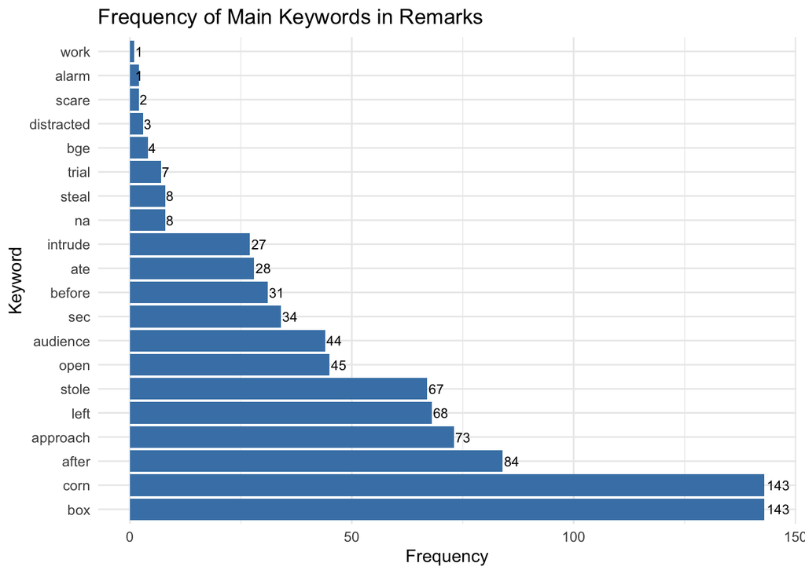

[output not shown]

#### 3.2.3 Exporting of Bex

- I will now export the dataset and treat manually treat the remarks in an Excel spreadsheet before uploading it again and creating a new dataframe. I will also print a Glimpse of Bex to have information before the manual changes

```
## Glimpse of the Bex Before treating Remarks:
```

```
## Rows: 2,742
## Columns: 16
## $ Time           <chr> "09:47:50", "09:50:07", "09:53:11", "09:54:28", "09:55:…
## $ Date           <dttm> 2022-09-27, 2022-09-27, 2022-09-27, 2022-09-27, 2022-0…
## $ Group          <chr> "Baie Dankie", "Baie Dankie", "Baie Dankie", "Baie Dank…
## $ MaleID         <chr> "Nge", "Nge", "Nge", "Nge", "Nge", "Nge", "Nge", "Nge",…
## $ FemaleID       <chr> "Oerw", "Oerw", "Oerw", "Oerw", "Oerw", "Oerw", "Oerw",…
## $ FemaleCorn     <dbl> 0, 0, 0, 0, 0, 0, 0, 0, 0, 0, 0, 0, 0, 0, 0, 7, 7, 7, 7…
## $ DyadDistance   <dbl> 2, 2, 1, 1, 0, 0, 0, 0, 0, 0, 0, 0, 1, 2, 2, 1, 1, 0, 0…
## $ DyadResponse   <chr> "Tolerance", "Tolerance", "Tolerance", "Tolerance", "To…
## $ OtherResponse  <chr> "No Response", "No Response", "No Response", "No Respon…
## $ Audience       <chr> "Obse; Oup; Sirk", "Obse; Oup; Sirk", "Oup; Sirk", "Sir…
## $ IDIndividual1  <chr> "No individual", "No individual", "No individual", "No …
## $ IntruderID     <chr> "No Intrusion", "No Intrusion", "No Intrusion", "No Int…
## $ Remarks        <chr> "No Remarks", "No Remarks", "Nge box did not open becau…
## $ MaleCorn       <dbl> 3, 3, 3, 3, 3, 3, 3, 3, 3, 3, 3, 3, 3, 3, 3, 3, 3, 3, 3…
## $ Intrusion      <dbl> 0, 0, 0, 0, 0, 0, 0, 0, 0, 0, 0, 1, 0, 0, 0, 0, 0, 0, 0…
## $ AmountAudience <dbl> 3, 3, 2, 1, 2, 2, 2, 1, 1, 2, 6, 6, 3, 2, 2, 2, 2, 2, 2…
```

```
## [1] "/Users/maki/Desktop/Master Thesis/BEX 2223 Master Thesis Maung Kyaw/IVPToleranceBex2223"
```

#### 3.2.4 Journal of manual changes in Bex excel spreadsheet

- Before treating all the data in the Remarks I will create a few columns to redistribute information
  1. **Context**: To add contextual information
  2. **SpecialBehaviour** : To report any particular behaviour an individual could have done during a trial
  3. **Got corn**, to see if the individual got the corn or not
- Also whenever i will have treated a remark, i will replace it with “Treated”. And if I have to delete the row I’ll write “Delete”. After re importing the data I will make a count of these changes to see if I still have the correct amount of cells and changes that have been done
- 1. Creation of the columns **Context**, **SpecialBehaviour** and **GotCorn**
- 2. Default values for the new columns are **NoContext**, **NoSpecialBehaviour** & **Yes**

  a.Context: **BoxMalfunction**, **BoxOpenedBefore**, **NoExperiment**, **Agonistic**, **Guat;Ap;Xian**, **CornLeak**, **BetweenGroupEncounter**, **ContactCalling**,

  b.SpecialBehaviour **Oerw;Vo;Exp**, **Sey;Ap;AfterOpen**, **Oerw;Vo;Exp,Nge;Vo;Exp**, **Sirk;ApAfter30**, **Sirk;Av;Oerw**, **Oerw;Lo**,**Sey;Sf;Oort,Oort;At;Kom**, **Kom;Ap;AfterOpen**, **Sey;Ch,Sirk**, **Xin;Hesitation**. **Xia;Sf;Piep**, **Pom;Sf;Xian**,**Kom;Sf;Oort**, **Sey;Sf;Sirk**, **Xia;Sf;Piep,Piep;Sf,XIa**, **Oort;At;Kom**, **Sey;Rt;Sho;Ap**, **Sho;Rt;Ginq;Ap**, **Buk;Sf;Ndaw**, **Sho;Rt;Ndaw;Ap**, **Oort;Sf;Kom**, **Ginq;Sho;Ap;After30**, **Ndaw;Sc,Buk;Sf**, **Ndaw;Ap;After30**, **Kom;Ap;After30**, **Xia;Piep;Ap;After30**, **Pom;Bi;Xian**, **Sho;Ndaw;Av;Buk**, **Kom;Sf;Oort**, **Kom;St;Oort,Oort;St;Kom**, **Sey;Hi;Sirk**, **Obse;Ap;Piep;Av**,**Piep;Sf;Xia**, **Sirk;ApWhenPartnerLeft**, **Sey;Hh;Sirk**, **Xia;Sf;Piep;Sc**, **Xia;Piep;ShareFood**, **Piep;Ap;After30,Xia;Mu;Piep**, **Oort;St;Sirk;Ja,Sey;Sf**, **Pom;Sf;Xian**, **Ndaw;ApWhenPartnerLeft**, **Xian;At;Pom,Gaya;Su**, **Xian;Sf;Pom**, **Xian;Hesitation**, **Xia;ApWhenPartnerLeft**,**Sirk;Hesitation**, **Ginq;Hesitation**, **Sey;Ap;Kom;Av**, **Oort;Sc;Kom**, **Xian; Pom**, **Pom;Ap;Xian**, **Pom;Ap;Xian,Xian;Rt**, **Sey;Ap;Sirk;Rt**, **Sey;St;Sirk;Ig**, **Xia;Asf;Piep**, **Piep;ApWhenPartnerLeft**, **Sho;Ap;After30**, **Ginq;ApWhenPartnerLeft**, **Pom;Sf;Xian;Sf;Pom**, **Xian;ApWhenPartnerLeft**, **Piep;Ch;Sirk**, **Sey;St;Sirk**, **Ndaw;Ap;After30**, **Xian;Ap;After30**, **Xian;St;Prai**, **Pom;Sf;Xian;Vc**, **Kom;Ap;After30**, **Kom;ApproachWithPartner**, **Oort;ApWhenPartnerLeft**, **Sho;Ap;After30**,**Ginq;Ap;After30**, **Ginq;ApproachWithPartner**, **Ndaw;Hesitation**, **Oerw;Hesitation**, **Oerw;ApWhenPartnerLeft**. **Piep;Ap;After30**, **Sirk;Ap;After30**, **Xia;Ap;After30**, **Ouli;Gr;BBOuli**, **Oerw;Ap;After30**, **Sirk;Hesitation**, **Sey;Ap;Sirk;Av**, **Ouli;Ap;Xia;Av**, **Xin;Ap;After30**, **Sho;Sf;Ginq;Sc**, **Xia;ApWhenPartnerLeft**, **Sey;Ap;Sirk;Ja**, **Nge;Oerw;ShareFood**, **Nge;Ap;Oerw;Oerw;At,Obse;At;Nge**,

  c.GotCorn: **No;Nge**, **No;Piep**, **No;Xian**, **No;Oort**, **No;Sirk**, **No;Kom**, **No;Ndaw**, **No;Kom**, **No;Oort**, **No;Xia**, **No;Buk**, **No;Sho**, **No;Sey,No;Piep**, **No;Ginq**
  4. Remarks: **Treated**, **TODelete**
- 4. Values set for exsting columns
  1. IntruderID: **Sey**, **Oerw**, **Guat**, **Kom**, **Gris**, **Sho**, **Oerw; Ouli**, **Guat; Gri**, **Xop**, **Obse**, **Oort**, **Obse; Sey**, **Ginq; Ghid**, **Xia**, **Grif**, **Sey**, **Gree; Gran**, **Godu; Gub**, **Gran**, **Oerw; Nak**, **Ghid**, **Buk**, **Oup**
  2. DyadDistance: **6**, **7**, **8**, **9** , **1**
  3. Audience: **UnidentifiedAudience**, **Ouli; Riss**, **Gris**, **Sey**, **Sey; Piep; Sirk, Oup Ome**
  4. IDIndividual1: **Piep**, **Oort; Kom**, **Ndaw; Buk**, **Sho; Ginq**, **Ndaw, Buk**, **Xian, Pom**, **Oort; Kom**, **Buk; Ndaw**, **Sirk; Sey**, **Xin; Ouli**, **Oerw; Nge**
  5. DyadResponse: **Tolerance**, **Not approaching; Losing interest**, **Losing interest; Intrusion**

### 3.3 Re Uploading the dataset after the treatment of the Remarks

- Now that I have manually treated the remarks in a spreadsheet I will re import the dataset

```
## Rows: 2,742
## Columns: 19
## $ Time             <chr> "09:47:50", "09:50:07", "09:53:11", "09:54:28", "09:5…
## $ Date             <dttm> 2022-09-27, 2022-09-27, 2022-09-27, 2022-09-27, 2022…
## $ Group            <chr> "Baie Dankie", "Baie Dankie", "Baie Dankie", "Baie Da…
## $ MaleID           <chr> "Nge", "Nge", "Nge", "Nge", "Nge", "Nge", "Nge", "Nge…
## $ FemaleID         <chr> "Oerw", "Oerw", "Oerw", "Oerw", "Oerw", "Oerw", "Oerw…
## $ FemaleCorn       <dbl> 0, 0, 0, 0, 0, 0, 0, 0, 0, 0, 0, 0, 0, 0, 0, 7, 7, 7,…
## $ DyadDistance     <dbl> 2, 2, 1, 1, 0, 0, 0, 0, 0, 0, 0, 0, 1, 2, 2, 1, 1, 0,…
## $ DyadResponse     <chr> "Tolerance", "Tolerance", "Tolerance", "Tolerance", "…
## $ OtherResponse    <chr> "No Response", "No Response", "No Response", "No Resp…
## $ Audience         <chr> "Obse; Oup; Sirk", "Obse; Oup; Sirk", "Oup; Sirk", "S…
## $ IDIndividual1    <chr> "No individual", "No individual", "No individual", "N…
## $ IntruderID       <chr> "No Intrusion", "No Intrusion", "No Intrusion", "No I…
## $ Remarks          <chr> "No Remarks", "No Remarks", "Treated", "Treated", "No…
## $ MaleCorn         <dbl> 3, 3, 3, 3, 3, 3, 3, 3, 3, 3, 3, 3, 3, 3, 3, 3, 3, 3,…
## $ Intrusion        <dbl> 0, 0, 0, 0, 0, 0, 0, 0, 0, 0, 0, 1, 0, 0, 0, 0, 0, 0,…
## $ AmountAudience   <dbl> 3, 3, 2, 1, 2, 2, 2, 1, 1, 2, 6, 6, 3, 2, 2, 2, 2, 2,…
## $ Context          <chr> "NoContext", "NoContext", "BoxMalfunction", "BoxOpene…
## $ SpecialBehaviour <chr> "NoSpecialBehaviour", "NoSpecialBehaviour", "Oerw;Vo;…
## $ GotCorn          <chr> "Yes", "Yes", "No;Nge", "Yes", "Yes", "Yes", "Yes", "…
```

| Time | Date | Group | MaleID | FemaleID | FemaleCorn | DyadDistance | DyadResponse | OtherResponse | Audience | IDIndividual1 | IntruderID | Remarks | MaleCorn | Intrusion | AmountAudience | Context | SpecialBehaviour | GotCorn |
| --- | --- | --- | --- | --- | --- | --- | --- | --- | --- | --- | --- | --- | --- | --- | --- | --- | --- | --- |
| 09:47:50 | 2022-09-27 | Baie Dankie | Nge | Oerw | 0 | 2 | Tolerance | No Response | Obse; Oup; Sirk | No individual | No Intrusion | No Remarks | 3 | 0 | 3 | NoContext | NoSpecialBehaviour | Yes |
| 09:50:07 | 2022-09-27 | Baie Dankie | Nge | Oerw | 0 | 2 | Tolerance | No Response | Obse; Oup; Sirk | No individual | No Intrusion | No Remarks | 3 | 0 | 3 | NoContext | NoSpecialBehaviour | Yes |
| 09:53:11 | 2022-09-27 | Baie Dankie | Nge | Oerw | 0 | 1 | Tolerance | No Response | Oup; Sirk | No individual | No Intrusion | Treated | 3 | 0 | 2 | BoxMalfunction | Oerw;Vo;Exp | No;Nge |
| 09:54:28 | 2022-09-27 | Baie Dankie | Nge | Oerw | 0 | 1 | Tolerance | No Response | Sirk | No individual | No Intrusion | Treated | 3 | 0 | 1 | BoxOpenedBefore | Sey;Ap;AfterOpen | Yes |
| 09:55:19 | 2022-09-27 | Baie Dankie | Nge | Oerw | 0 | 0 | Tolerance | No Response | Sey; Sirk | No individual | No Intrusion | No Remarks | 3 | 0 | 2 | NoContext | NoSpecialBehaviour | Yes |
| 09:56:56 | 2022-09-27 | Baie Dankie | Nge | Oerw | 0 | 0 | Tolerance | No Response | Sey; Sirk | No individual | No Intrusion | No Remarks | 3 | 0 | 2 | NoContext | NoSpecialBehaviour | Yes |

- And Check for any remaining NA’s in BexClean

```
## Number of NA entries in Context:  0
```

```
## Number of NA entries in SpecialBehaviour:  0
```

```
## Number of NA entries in GotCorn:  0
```

```
## Number of NA entries in BexClean:  0
```

### 3.4 Time - Creation of Period and Hour

- Time : I considered looking at the time sections in which we did the expermiment. I will thus look at the time ranges (max and min in the day / latest and earliest time) before separating the day in different sections to have an idea in which part of the day most of the experiments occured. This will not be used in my analysis, but if I wanted to, I could interesting to compare the amount of experimentations made per day and have a line indicating the time of sunrise.
- The **Minimum Time** in the dataset is **06:03:26*** while the **Maximum Time** is at **16:36:59**
- In my box experiment I have this variable called time that tells me when the experiment was done. I don’t think I need this information per se. I was wondering if it could be easy and interesting to see from when to when the time occurs and then separate this time in a few sections like early, monring, morning, miday, afternoon, end of the day
- a.6 to 8 : Early morning b.8 to 10: Morning c.10 to 12: Noon d.12 to 14: Afternoon e.14 to 17: End of the day
- Last, I want to create a variable called Hour that will take the value in Time and round it to the hour in which it is ex: from 06:00 to 06:59 -> 6, from 07:00 to 07:59 -> 7 etc…
- This will allow me to see when most of the trials occured with more detail and I will be to see in which hour most of the trial happened. Nevertheless Period will be better for an improved readability

### 3.5 Date - Creation of Month and Day

- i want to Create a variable called month to see the month of the experiment and day so I know which day of the experiment it was (1st, 10th, 1000th..)

### 3.6 Male and Female ID - Creation of Dyad, Trial and Session

- I will use Female and Male ID to create different variables
  1. While checking if there are still any mistakes in **FemaleID and MaleID** using **unique**, I saw that some of the names are in the wrong rows. I want the **3 letter male codes** whether they are in the column FemaleID or MaleID to be in the **new column Male** while I want the **4 letter female codes** whether they are in FemaleID or MaleID to be in the **new column Female** before checking again with unique that the transformation worked. I will use mutate

```
## Unique Female IDs: Sirk Ginq Piep Oerw Xin Ndaw Xia Sey Ouli Nge Oort Xian Guat Kom
```

```
## Unique Male IDs: Sey Sho Xia Nge Ouli Buk Piep Sirk Xin Oerw Kom Pom Oort
```

|  | Buk | Kom | Nge | Oerw | Oort | Ouli | Piep | Pom | Sey | Sho | Sirk | Xia | Xin |
| --- | --- | --- | --- | --- | --- | --- | --- | --- | --- | --- | --- | --- | --- |
| Ginq | 6 | 0 | 0 | 0 | 0 | 0 | 0 | 0 | 0 | 277 | 0 | 0 | 0 |
| Guat | 0 | 0 | 0 | 0 | 0 | 0 | 0 | 5 | 0 | 0 | 0 | 0 | 0 |
| Kom | 0 | 0 | 0 | 0 | 29 | 0 | 0 | 0 | 0 | 0 | 0 | 0 | 0 |
| Ndaw | 259 | 0 | 0 | 0 | 0 | 0 | 0 | 0 | 0 | 0 | 0 | 0 | 0 |
| Nge | 0 | 0 | 0 | 19 | 0 | 0 | 0 | 0 | 0 | 0 | 0 | 0 | 0 |
| Oerw | 0 | 0 | 164 | 0 | 0 | 0 | 0 | 0 | 0 | 0 | 0 | 0 | 0 |
| Oort | 0 | 337 | 0 | 0 | 0 | 0 | 0 | 0 | 0 | 0 | 0 | 0 | 4 |
| Ouli | 0 | 0 | 0 | 0 | 0 | 0 | 0 | 0 | 0 | 0 | 0 | 0 | 159 |
| Piep | 0 | 0 | 0 | 0 | 0 | 0 | 0 | 0 | 0 | 0 | 0 | 575 | 0 |
| Sey | 0 | 0 | 0 | 0 | 0 | 0 | 0 | 0 | 0 | 0 | 17 | 0 | 0 |
| Sirk | 0 | 0 | 0 | 0 | 0 | 0 | 0 | 0 | 570 | 0 | 0 | 0 | 0 |
| Xia | 0 | 0 | 0 | 0 | 0 | 0 | 35 | 0 | 0 | 0 | 0 | 0 | 0 |
| Xian | 0 | 0 | 0 | 0 | 0 | 0 | 0 | 259 | 0 | 0 | 0 | 0 | 0 |
| Xin | 0 | 0 | 0 | 0 | 0 | 27 | 0 | 0 | 0 | 0 | 0 | 0 | 0 |

1. Create a variable called Male that in each row will take the name of the **3 letter code** that is either in MaleID or Female ID and a variable called Female that in each row will take the name of the **4 letter code** that is either in MaleID or FemaleID

```
## Unique Dyads: Sey Sirk Sho Ginq Xia Piep Nge Oerw Xin Ouli Buk Ndaw Buk Ginq Kom Oort Pom Xian Pom Guat Xin Oort
```

| Var1 | Freq |
| --- | --- |
| Buk Ginq | 6 |
| Buk Ndaw | 259 |
| Kom Oort | 366 |
| Nge Oerw | 183 |
| Pom Guat | 5 |
| Pom Xian | 259 |
| Sey Sirk | 587 |
| Sho Ginq | 277 |
| Xia Piep | 610 |
| Xin Oort | 4 |
| Xin Ouli | 186 |

```
## Unique Male-Female Combinations:
```

```
## # A tibble: 11 × 2
##    Male  Female
##    <chr> <chr>
##  1 Sey   Sirk
##  2 Sho   Ginq
##  3 Xia   Piep
##  4 Nge   Oerw
##  5 Xin   Ouli
##  6 Buk   Ndaw
##  7 Buk   Ginq
##  8 Kom   Oort
##  9 Pom   Xian
## 10 Pom   Guat
## 11 Xin   Oort
```

```
## [1] "Wrong Rows:"
```

```
##  [1]  613  614  615  616  617  931 2710 2711 2712 2713
```

```
## [1] "Wrong Dyads:"
```

```
##  [1] "Buk Ginq" "Buk Ginq" "Buk Ginq" "Buk Ginq" "Buk Ginq" "Buk Ginq"
##  [7] "Xin Oort" "Xin Oort" "Xin Oort" "Xin Oort"
```

```
## Rows to correct Sho Ginq:
```

```
## [1] 613 614 615 616 617 931
```

```
## Rows to correct Kom Oort:
```

```
## [1] 2710 2711 2712 2713
```

```
## Wrong Rows After Correction:
```

```
## integer(0)
```

```
## Wrong Dyads After Correction:
```

```
## character(0)
```

```
## All dyads are now correct.
```

```
## Unique Dyads after correction: Sey Sirk Sho Ginq Xia Piep Nge Oerw Xin Ouli Buk Ndaw Kom Oort Pom Xian Pom Guat
```

| Var1 | Freq |
| --- | --- |
| Buk Ndaw | 259 |
| Kom Oort | 370 |
| Nge Oerw | 183 |
| Pom Guat | 5 |
| Pom Xian | 259 |
| Sey Sirk | 587 |
| Sho Ginq | 283 |
| Xia Piep | 610 |
| Xin Ouli | 186 |

```
## Number of rows changed to Sho Ginq: 6
```

```
## Number of rows changed to Kom Oort: 4
```

3. Create the variable called **Trial** where the data will be **sorted by date and dyad** in order to see how many trials have been done with each individual: **One row (per dyad) = one trial** and the variable called **Day** where the data will be **sorted by date and dyad and day** in order to see how many sessions have been done with each individual: **One day (per dyad) = one session** Now, let’s proceed with creating the Dyad variable, Trial, and Day:
4. Make a summary of trial and session so I can see see how many trials and sessions have been done with the individuals

```
## Trial Summary:
```

Summary of Trials

| Dyad | Amount of Trials |
| --- | --- |
| Xia Piep | 610 |
| Sey Sirk | 587 |
| Kom Oort | 370 |
| Sho Ginq | 283 |
| Buk Ndaw | 259 |
| Pom Xian | 259 |
| Xin Ouli | 186 |
| Nge Oerw | 183 |
| Pom Guat | 5 |

```
##
## Day Summary:
```

Summary of Days

[output not shown]

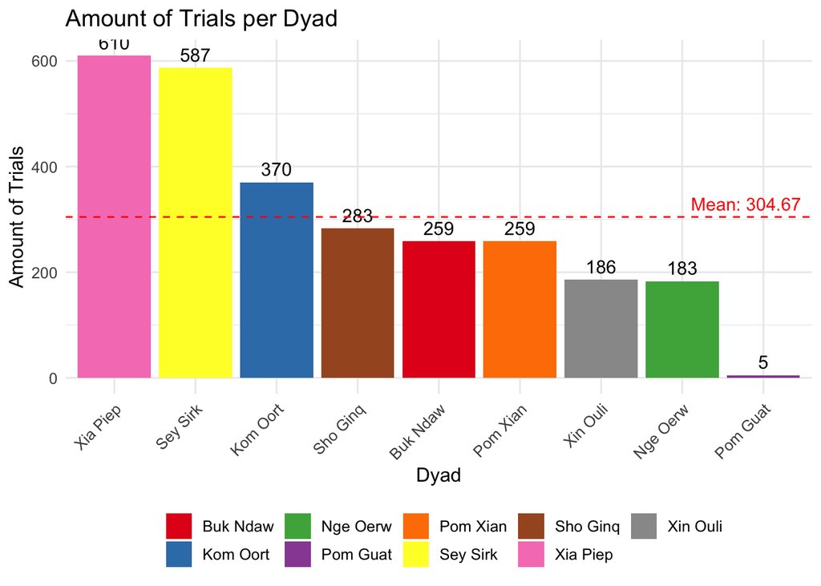

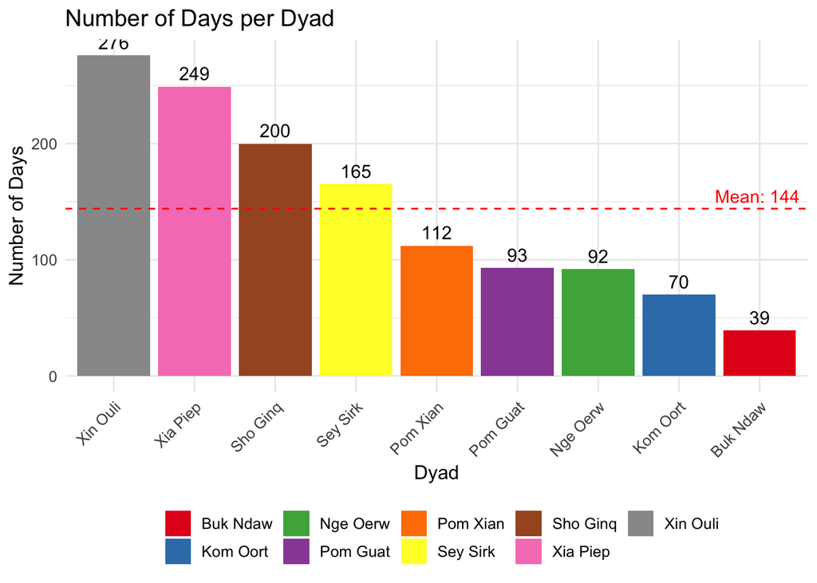

5. After relfection I decided to **remove every column** that is with PomGuat since they are not enough trials for this Dyad and since we then changed PomGuat for PomXian. I have 5 occurnces to change. For easier manipulation I will remove every row where there is **Guat**

```
## Change in Rows:  -5
```

### 3.7 Female and Male Placement Corn

- The idea is that for each Dyad, we gave an amount of corn to attract the monkey of a dyad to the right distance of his partner for a trial by putting corn in experiment box that he could get by approaching. We repeated this step as much as needed to have our Dyad at the desired distance to continue the trials from the previous day of experimentation. This means I will only Keep the last number per dyad and day for each day.
- I decided to create **two variables**, that are called **PlacementMale** and **PlacementFemale** that will only keep the final amount of corn given to each individual within a day of experiment

```
## Placement columns were created successfully.
```

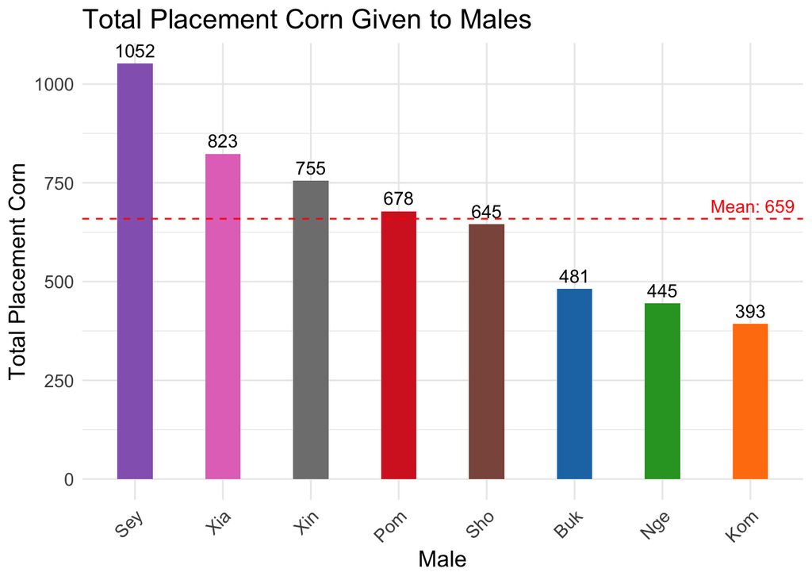

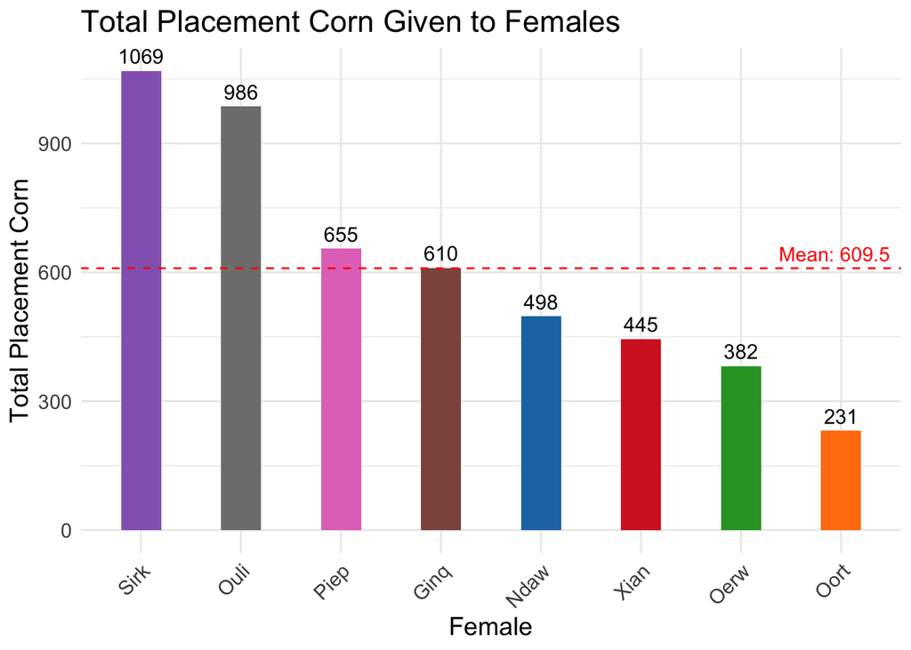

### 3.8 DyadDistance - Creation of proximity

- I would like to create a variable called proximity to have another measure of the proximity of the individuals.
- First lets look at the maximum and minimum distance found in Dyad Distance

```
## Maximum Distance: 10
```

```
## Minimum Distance: 0
```

  | DyadDistance | Frequency |
  | --- | --- |
  | 0 | 904 |
  | 1 | 644 |
  | 2 | 471 |
  | 3 | 303 |
  | 4 | 217 |
  | 5 | 133 |
  | 6 | 41 |
  | 7 | 13 |
  | 8 | 9 |
  | 9 | 1 |

  [output cut: 1 more lines]

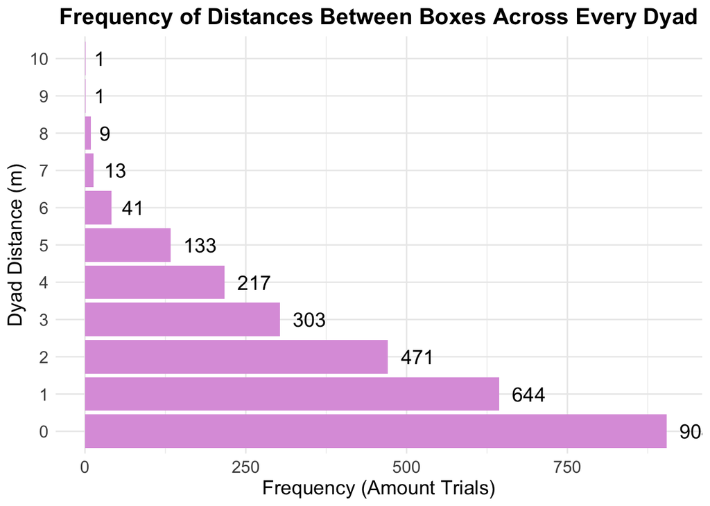

- Now lets create a new variable called **Proximity** using the distances found in **DyadDistance** on the following model:
  1. 0 = Contact
  2. 1 - 2 = 1-2
  3. 2 - 3 = 2-3
  4. 4 - 5 = 4-5
  5. 5 - 10 = +5

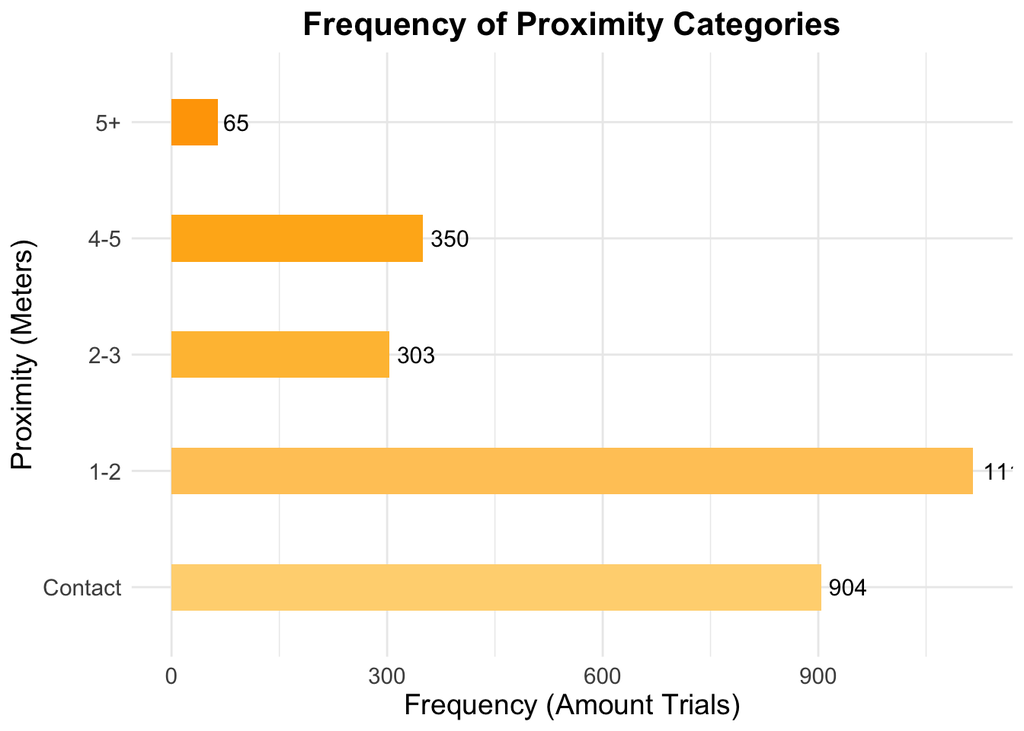

# UPDATES FROM HERE

### 3.9.1 Dyad Response - Corrections and detailed cleaning

- Reminder: The different behaviors that are coded in **DyadResponse** are: **Distracted**, **Female aggress male**, **Male aggress female**, **Intrusion**, **Loosing interest**, **Not approaching**, **Tolerance** and **Other**
  - I will change the columns associated to each behavior (i.e. Response) of **DyadResponse** into dichotomic variables in order to see the frequency of each behaviour
  - This will allow me to see which behavior occurred more than others, and what differences are between dyads
  - As multiple behaviours could occur within the same trial, multiple responses (data entries) can be found in a single cell. I will create a hierarchy to reduce the amount of behaviors assigned to each trial (if there is more than one).
    1. correct any potential discrepancies (ex. if tolerance and aggression occured within the same trial aggression>tolerance)
    2. assign as few labels per trial, ideally one using a hierarchy among the occuring behaviours to choose which response to keep
    3. get a better view and understanding of the data and the most common behaviours produced by each dyad producing plots and tables
    4. if necessary create new variables that can complement redistribute the information initally found in the column
- I will create some tables to have a better understanding of the state of the column dyadresponse and the different existing combinations at this point
- Also I will create the hierarchy before implementing in the dataset

### 3.9.2 Dyad Response description

- I need to know how many different combinations exist within DyadResponse and how many occurnces/cells have more than one response per cell. I need the code to not take in account the order but rather the responses in themselves
- I want one table for the Different combinantions and one showing the differernt combinations for only ONE response per cell, in a second table

```
## Number of rows with multiple entries in DyadResponse:  271
```

```
## Rows with multiple entries in DyadResponse:  3 4 13 53 58 64 68 71 72 84 88 89 97 98 113 133 137 192 194 244 275 277 278 284 289 298 302 304 318 322 326 327 328 331 341 346 347 367 368 387 388 391 397 409 454 468 469 482 497 510 511 522 529 536 597 600 626 629 687 696 706 711 713 726 740 748 749 …
```

```
## Total number of rows in DyadResponse:  2737
```

```
## Number of rows with a single entry in DyadResponse:  2466
```

```
## Number of rows with multiple entries in DyadResponse:  271
```

```
## Sum of single and multiple entry rows:  2737
```

```
##
##
## Table: Unique DyadResponse Combinations and Their Frequencies
##
## |Combination                                       | Frequency|
## |:-------------------------------------------------|---------:|
## |Intrusion;Tolerance                               |        49|
## |Losing interest;Not approaching                   |        47|
## |Intrusion;Not approaching                         |        30|
## |Male aggress female;Tolerance                     |        27|
## |Looks at partner;Tolerance                        |        23|
## |Losing interest;Tolerance                         |        22|
## |Female aggress male;Tolerance                     |        19|
## |Looks at partner;Not approaching                  |         9|
## |Other;Tolerance                                   |         7|
## |Distracted;Not approaching                        |         6|
## |Not approaching;Tolerance                         |         4|
## |Distracted;Losing interest                        |         3|
## |Female aggress male;Male aggress female;Tolerance |         3|
## |Female aggress male;Not approaching               |         3|
## |Distracted;Tolerance                              |         2|
## |Female aggress male;Intrusion;Tolerance           |         2|
## |Male aggress female;Not approaching               |         2|
## |Distracted;Intrusion;Not approaching              |         1|
## |Distracted;Intrusion;Tolerance                    |         1|
## |Female aggress male;Intrusion                     |         1|
## |Intrusion;Losing interest                         |         1|
## |Intrusion;Losing interest;Not approaching         |         1|
## |Intrusion;Male aggress female                     |         1|
## |Intrusion;Not approaching;Tolerance               |         1|
## |Looks at partner;Losing interest;Not approaching  |         1|
## |Looks at partner;Male aggress female              |         1|
## |Looks at partner;Male aggress female;Tolerance    |         1|
## |Looks at partner;Other;Tolerance                  |         1|
## |Losing interest;Not approaching;Tolerance         |         1|
## |Not approaching;Other                             |         1|
```

```
##
##
## Table: Rows with Single Responses in DyadResponse
##
## |DyadResponse        | Frequency|
## |:-------------------|---------:|
## |Tolerance           |      1809|
## |Not approaching     |       465|
## |Male aggress female |        73|
## |Intrusion           |        51|
## |Losing interest     |        37|
## |Female aggress male |        18|
## |Other               |         9|
## |Distracted          |         4|
```

```
##
##
## Table: Rows with Multiple Responses in DyadResponse
##
## |Combination                                       | Frequency|
## |:-------------------------------------------------|---------:|
## |Intrusion;Tolerance                               |        49|
## |Losing interest;Not approaching                   |        47|
## |Intrusion;Not approaching                         |        30|
## |Male aggress female;Tolerance                     |        27|
## |Looks at partner;Tolerance                        |        23|
## |Losing interest;Tolerance                         |        22|
## |Female aggress male;Tolerance                     |        19|
## |Looks at partner;Not approaching                  |         9|
## |Other;Tolerance                                   |         7|
## |Distracted;Not approaching                        |         6|
## |Not approaching;Tolerance                         |         4|
## |Distracted;Losing interest                        |         3|
## |Female aggress male;Male aggress female;Tolerance |         3|
## |Female aggress male;Not approaching               |         3|
## |Distracted;Tolerance                              |         2|
## |Female aggress male;Intrusion;Tolerance           |         2|
## |Male aggress female;Not approaching               |         2|
## |Distracted;Intrusion;Not approaching              |         1|
## |Distracted;Intrusion;Tolerance                    |         1|
## |Female aggress male;Intrusion                     |         1|
## |Intrusion;Losing interest                         |         1|
## |Intrusion;Losing interest;Not approaching         |         1|
## |Intrusion;Male aggress female                     |         1|
## |Intrusion;Not approaching;Tolerance               |         1|
## |Looks at partner;Losing interest;Not approaching  |         1|
## |Looks at partner;Male aggress female              |         1|
## |Looks at partner;Male aggress female;Tolerance    |         1|
## |Looks at partner;Other;Tolerance                  |         1|
## |Losing interest;Not approaching;Tolerance         |         1|
## |Not approaching;Other                             |         1|
```

### 3.9.3 Dyad Response Hierarchy

Display the rows with more than 1 entry in DyadResponse knitr::kable(BexClean[beforesummaryrowswithmultipleentries_1, ])

- Print the amount of cells with more than 1 entry and the total number of rows cat(“Number of rows with more than 1 entry in DyadResponse:”, length(beforesummaryrowswithmultipleentries_1), “”)
- C. Identify Rows with more than 2 entry

```
## Number of rows with more than 1 entry in DyadResponse:  271
```

```
## Unique Combinations and Counts for More than 1 Entry:
```

```
##  Distracted &  Intrusion  2
##  Female aggress male &  Intrusion 2
##  Looks at partner &  Other 1
##  Losing interest &  Intrusion 1
##  Losing interest &  Looks at partner 1
##  Male aggress female &  Female aggress male 3
##  Male aggress female &  Looks at partner 1
##  Not approaching &  Intrusion 1
##  Not approaching &  Losing interest 1
## Distracted &  Losing interest 3
## Female aggress male &  Intrusion 1
## Female aggress male &  Not approaching 3
## Losing interest &  Intrusion 1
## Male aggress female &  Intrusion 1
## Male aggress female &  Looks at partner 1
## Male aggress female &  Not approaching 2
## Not approaching &  Distracted 7
## Not approaching &  Intrusion 32
## Not approaching &  Looks at partner 10
## Not approaching &  Losing interest 49
## Not approaching &  Other  1
## Tolerance &  Distracted   3
## Tolerance &  Female aggress male 24
## Tolerance &  Intrusion    53
## Tolerance &  Looks at partner 25
## Tolerance &  Losing interest 23
## Tolerance &  Male aggress female 31
## Tolerance &  Not approaching 6
## Tolerance &  Other        8
```

[output not shown]

6. Male agress female > Not approaching : Remove Not approaching if there is Male aggress female (2x)

```
## Change in Occurrences for the Chunk (Male aggress female > Not approaching):  -2
```

7. Tolerance > Distracted: Remove Distracted if there is tolerance (3x)

```
## Change in Occurrences for the Chunk Tolerance > Distracted:  -3
```

```
## Change in Occurrences for the Chunk (Tolerance & Female aggress male):  -24
```

```
## Change in Occurrences for the Chunk (Tolerance & Losing interest):  0
```

```
## Change in Occurrences for the Chunk (Tolerance & Male aggress female):  -28
```

11.Tolerance > Not approaching: Remove Not approaching if there is tolerance (6x)

```
## Change in Occurrences for teh Chunk (Tolerance & Not approaching):  -6
```

SEE WHEN AND HOW TO Put ThIS CODE TO REPLACE PREIVOSU NUMBERS:

# 1. Aggression > Tolerance

BexClean <- BexClean[!(grepl(“Tolerance”, BexClean$DyadResponse) & (grepl("Female aggress male", BexClean$DyadResponse) | grepl(“Male aggress female”, BexClean$DyadResponse))), ]

# 2. Tolerance > Not approaching

BexClean <- BexClean[!(grepl(“Not approaching”, BexClean$DyadResponse) & grepl("Tolerance", BexClean$DyadResponse)), ]

# 3. Tolerance > Loosing interest

BexClean <- BexClean[!(grepl(“Losing interest”, BexClean$DyadResponse) & grepl("Tolerance", BexClean$DyadResponse)), ]

# 4. Tolerance > Intrusion

BexClean <- BexClean[!(grepl(“Intrusion”, BexClean$DyadResponse) & grepl("Tolerance", BexClean$DyadResponse)), ]

# 5. Intrusion > Loosing interest

BexClean <- BexClean[!(grepl(“Losing interest”, BexClean$DyadResponse) & grepl("Intrusion", BexClean$DyadResponse)), ]

# 6. Intrusion > Not approaching

BexClean <- BexClean[!(grepl(“Not approaching”, BexClean$DyadResponse) & grepl("Intrusion", BexClean$DyadResponse)), ]

# 7. Not approaching > Looks at partner

# Code every look at partner as not approaching and keep the count of looks at partner as additional information

# 8. Define distracted

# Not approaching > Distracted

BexClean <- BexClean[!(grepl(“Distracted”, BexClean$DyadResponse) & grepl("Not approaching", BexClean$DyadResponse)), ]

# 9. Other > Look case by case and categorize depending on behavior

# Final clean-up and reporting

knitr::kable(BexClean, col.names = colnames(BexClean), caption = “Cleaned DyadResponse Data”)

- Code to display rows numbers and the response in DyadResponse that have mroe than one entry
- Other Reponse - DEtailed cleaning to delete the column
- Audience - Creation of Amount Audience and Density
- ID Individua1 - Not sure yet
- Intruder ID
- Remarks - Detailed Cleaning
- Intrusion
- Not Approaching
- Lossing Interest
- Distracted
- MultipleResponse
- Amount Audience
- DyadDistance
- Distance
- No trial

#### Code to keep and place again

# Code to settle

I also chose to directly create new dichotomic variables for “Not approaching”, “Intrusion”, “Losing interest”, “Distracted”, for this I would like the function to 1.Check if there is a **value different than “No individual”** 2.**If the value ≠“No individual”** then I want it to **take the response found in “DyadResposne”**

```
## The 'MultipleResponses' column already exists. No changes made.
```

```
## Occurrences of 'Not approaching' in DyadResponse: 564
```

```
## Occurrences of 'Intrusion' in DyadResponse: 135
```

```
## Occurrences of 'Losing interest' in DyadResponse: 112
```

```
## Occurrences of 'Distracted' in DyadResponse: 14
```

```
## Occurrences of '1' in 'NotApproaching': 0
```

```
## Occurrences of '1' in 'Intrusion': 56
```

```
## Occurrences of '1' in 'LosingInterest': 0
```

```
## Occurrences of '1' in 'Distracted': 0
```

### Exploratory Graph (To organise)

####Dyad, Distance & Date

- Trials of grpahs, I will have to check all of them
- My goal here is too see if each dyad have an general evolution of their dyad distance trough time and how many varaition do they have

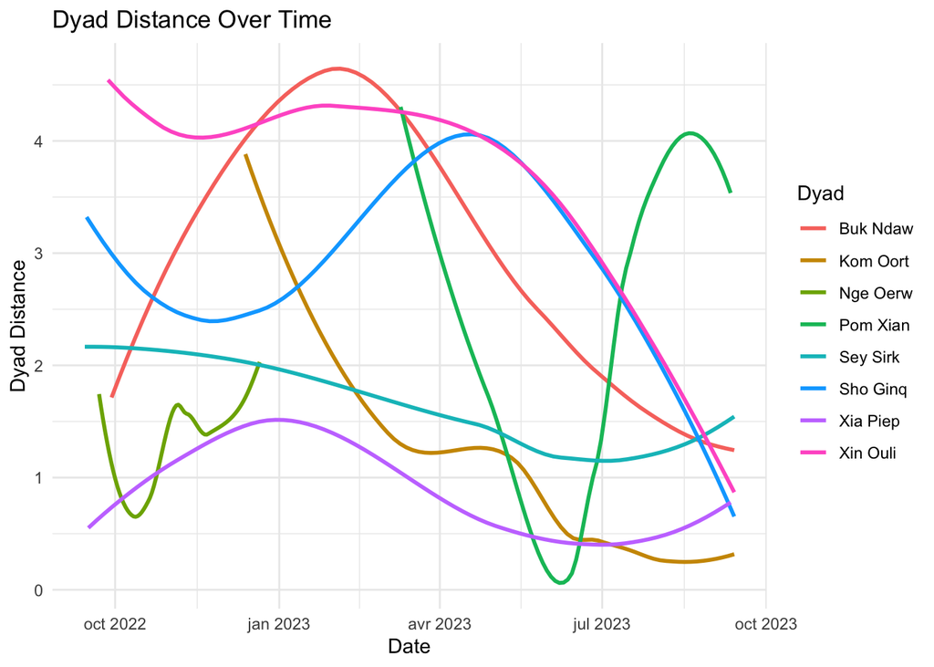

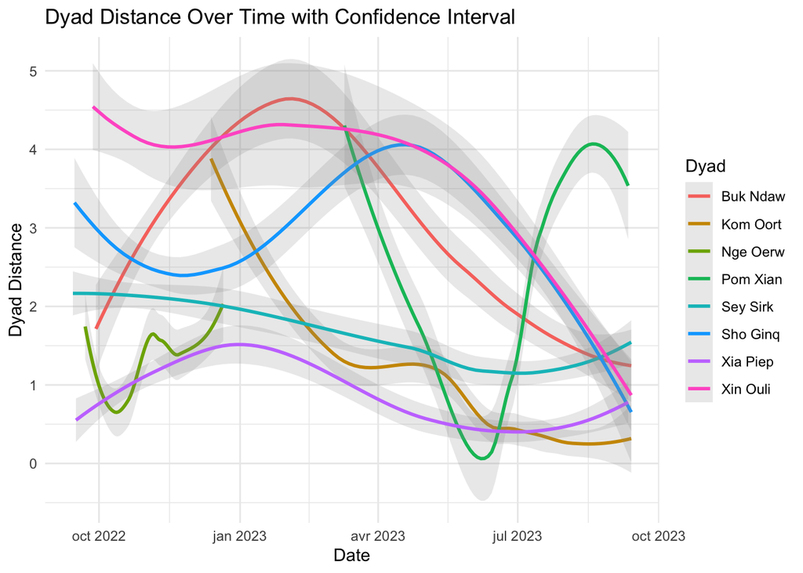

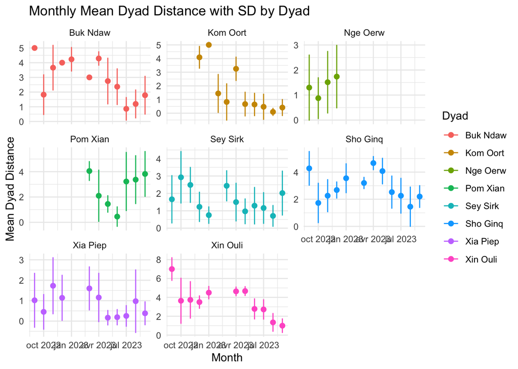

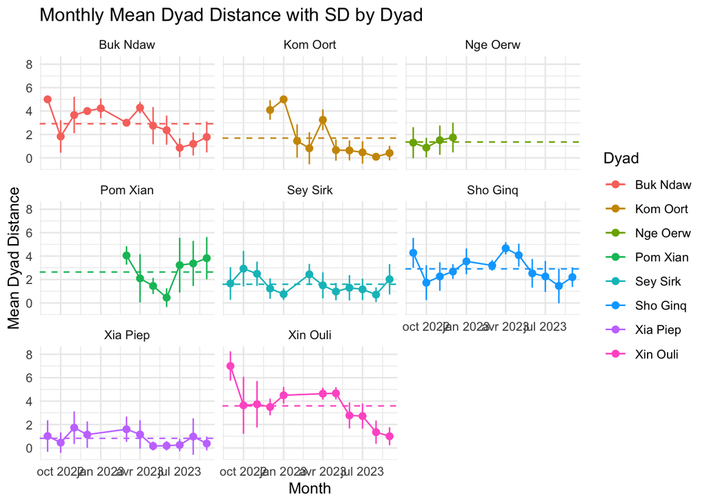

[figure not shown]

- I want to use the date to know **how many sessions** have been done with each dyads in my experiment. * I will create a variable called **Session** where **1 session = 1 day** * The data has values from the **14th of September 2022** until the **13th of September 2023** * I will also create a variable called **Trial** to know how many trials have been done with each dyad where **1 row = 1 trial**

[output not shown]

- But before I may want to make a few changes already by merging **Male corn** and **Male placement corn** into ” Male corn” and maybe replacing all of the NA’s in “Other response” by response

#Lines to check unique values in MaleFemaleID to see if they are any problems with it # Unique values in MaleID unique_male_ids <- unique(BexClean$MaleID)

# Unique values in FemaleID

unique_female_ids <- unique(Bex$FemaleID)

# Sections below are here for the organization of my paper and will be worked on once the data cleaning and exploration is done

## 3. Describing the data

## 4.Visualizing the data

## 5.Research question & Hypothesis

### Research question

- What factors influence the rate at which individuals (vervets) learn to tolerate each other in a controlled box experiment?
- Ex: The rate at which individuals (vervets) learn to tolerate each other in a box experiment is influenced by social factors (audience, social network, behavior of the partner) and idioyncratic factors (age, rank)

### Hypothesis

- 1. Hypothesis about the Presence of High-Ranking Individuals:

The presence of a higher number of high-ranking individuals in the audience will negatively correlate with the level of tolerance achieved among vervets in the box experiment. This is expected to result in higher frequencies of aggressive behaviors, intrusions, and loss of interest, particularly from lower-ranking individuals.

- 2. Hypothesis about Partner Agonistic Behaviors:

Vervets tolerance levels in the box experiment will be influenced by their partner’s display of agonistic behaviors. Specifically, partners who exhibit more frequent agonistic behaviors towards their partner will lead to decrease in their motivation to participate in future trials.

- 3. Hypothesis about the Establishment of an Optimal Distance:

During the box experiment, vervet dyads will establish an “optimal” distance for interaction, characterized by a higher frequency of tolerance compared to other distances. This optimal distance is expected to signify that the individuals tolerate each other more effectively at this specific proximity .

- 4. Hypothesis about Age and Rank:

The age and rank of individual vervets within the group will influence the success of the trials in the box experiment. Specifically, older and higher-ranking individuals are expected to exhibit lower rates of success compared to dyads consisting of younger and lower-ranked individuals. This decrease in success is anticipated to be associated with a higher frequency of aggressive behaviors displayed by older and higher-ranking individuals towards their partners. (I’m not sure this hypothesis makes sens, I have the feeling age and rank must have an influence but I don’t know how to put it, I will think about it)

- 5. Hyptohesis about seasonality

## 6.Statistical tests and analisis of the data

### Statistical tests

- **Hypothesis 1**: Influence of High-Ranking Individuals

Variables Needed:

**DyadResponse** (specifically, “aggression” responses) **Amountaudience** (to measure the number of individuals in the audience) **Audience…15** (to identify the names of individuals in the audience for calculating dominance ranks) **Elo rating** of the individuals based on the ab libitum data collected in IVP (which I have to calculate asap)

Statistical Analysis:**Logistic Regression**, as it could analyze the influence of high-ranking individuals on the occurrence of aggression in dyad responses. This will help determine whether the presence of high-ranking individuals affects the likelihood of aggression.

- **Hypothesis 2**: Impact of Partner’s Agonistic Behaviors

Variables Needed:

- **DyadResponse** (specifically, “aggression” responses)
- **MaleagressF** (male’s aggression towards female)
- **FemaleaggressM** (female’s aggression towards male)

Statistical Analysis: **Logistic Regression** as it could be used to assess how the occurrence of aggression in dyad responses is influenced by the partner’s gender-specific agonistic behaviors.

- **Hypothesis 3**: Identification of an Optimal Interaction Distance

Variables Needed:

- **DyadDistance** (distance between boxes)
- **Tolerance** (as a binary outcome)

Statistical Analysis: **generalized Linear Model (GLM)** to investigate whether there is an optimal distance that leads to a higher likelihood of tolerance (Tolerance = 1).

- **Hypothesis 4**: Role of Age and Rank

Variables Needed:

- **Tolerance** (as a binary outcome)
- **Male and Female** (to identify individuals’ ages and ranks)
- **Dyad** (to link individuals to dyads)
- **Birthdate** to calculate the age of each individual

Statistical Analysis: **Logistic Regression** Logistic regression can be employed to determine whether the age and rank of individual vervets within dyads have an impact on the likelihood of tolerance (Tolerance = 1).

- **Hypothesis 5**: Influence of Seasonality

Variables Needed:

- **Date** (to categorize data into seasons)
- **Trial** (to count the number of trials in each season) and the data for at least 365 days so i can separate the data in 4 (1 year = 4 seasons = 12*4 month) to see if they may be an effect of seasonality on the motivation (amount of trials) of the dyads

Statistical Analysis:

ANOVA or Kruskal-Wallis Test: Depending on the distribution of your trial data, you can use either ANOVA (if the data are normally distributed) or the Kruskal-Wallis test (for non-normally distributed data) to assess the impact of seasonality on the number of trials. If significant differences are found, you can follow up with post-hoc tests to identify which seasons differ from each other. Please note that the effectiveness of these analyses may depend on the distribution of your data and specific research objectives. You may also consider conducting exploratory data analysis (e.g., visualization) to gain a better understanding of your dataset before performing these analyses. Additionally, if you have specific questions about data preprocessing or variable transformations, feel free to ask for further guidance. –> I took this from ChatGPT, I have to look more into it

**REMARKS**: So here are a few updates I made in the document. I also planned to send my cleaned data to Radu (the statistician of UNINE) as he was keen to help me find the right test. Of course I will also look again in Bshary’s and Charlotte’s work with the boxes and improve these suggestions that are quite simple for now

Also I still have to clean the last grpahs about male/female aggression as I didn’t finish that yet. I juste wanted to share my hypothesis and ideas for statistics so I can soon go into the “serious” work

Anyway, thank you in advance for your help <3

Michael